# Revenue Analysis

S. 3

Laurens

May 30, 2025

# Data overview

```
## Rows: 344
## Columns: 4
## $ assembly                      <chr> "WA", "WA", "WA", "WA", "WA", "WA", "WA"…
## $ revenue_item                  <chr> "Property Rates", "Property Rates", "Pro…
## $ year                          <dbl> 2018, 2019, 2020, 2021, 2022, 2023, 2024…
## $ contribution_to_total_revenue <dbl> 0.0, 0.0, 1.8, 0.0, 0.1, 1.7, 3.8, 4.8, …
```

```
##    assembly         revenue_item            year
##  Length:344         Length:344         Min.   :2017
##  Class :character   Class :character   1st Qu.:2019
##  Mode  :character   Mode  :character   Median :2021
##                                        Mean   :2021
##                                        3rd Qu.:2023
##                                        Max.   :2024
##
##  contribution_to_total_revenue
##  Min.   : 0.0
##  1st Qu.: 0.4
##  Median : 8.2
##  Mean   :12.6
##  3rd Qu.:20.3
##  Max.   :71.9
##  NA's   :11
```

```
## # A tibble: 10 × 4
##    assembly revenue_item    year contribution_to_total_revenue
##    <chr>    <chr>          <dbl>                         <dbl>
##  1 WA       Property Rates  2018                           0
##  2 WA       Property Rates  2019                           0
##  3 WA       Property Rates  2020                           1.8
##  4 WA       Property Rates  2021                           0
##  5 WA       Property Rates  2022                           0.1
##  6 WA       Property Rates  2023                           1.7
##  7 WA       Property Rates  2024                           3.8
##  8 WA       Other Rates     2018                           4.8
##  9 WA       Other Rates     2019                           5.9
## 10 WA       Other Rates     2020                           6.7
```

```
## [1] "Property Rates"            "Other Rates"
## [3] "Fees"                      "Fines"
## [5] "Licences"                  "Land (incl Miscellaneous)"
## [7] "Rent"                      "Investment"
```

```
## [1] 2018 2019 2020 2021 2022 2023 2024 2017
```

```
## [1] "WA"            "TAMALE"        "BOLGATANGA"    "YENDI"
## [5] "EAST MAMPRUSI" "WEST GONJA"
```

```
##    Min. 1st Qu.  Median    Mean 3rd Qu.    Max.    NA's
##     0.0     0.4     8.2    12.6    20.3    71.9      11
```

```
## --- Distribution of Observations ---
```

Assembly Distribution

| assembly | n | Proportion |
| --- | --- | --- |
| BOLGATANGA | 64 | 0.186 |
| EAST MAMPRUSI | 56 | 0.163 |
| TAMALE | 56 | 0.163 |
| WA | 56 | 0.163 |
| WEST GONJA | 56 | 0.163 |
| YENDI | 56 | 0.163 |

Revenue Item Distribution

| revenue_item | n | Proportion |
| --- | --- | --- |
| Fees | 43 | 0.125 |
| Fines | 43 | 0.125 |
| Investment | 43 | 0.125 |
| Land (incl Miscellaneous) | 43 | 0.125 |
| Licences | 43 | 0.125 |
| Other Rates | 43 | 0.125 |
| Property Rates | 43 | 0.125 |
| Rent | 43 | 0.125 |

Year Distribution

| year | n | Proportion |
| --- | --- | --- |
| 2017 | 8 | 0.023 |
| 2018 | 48 | 0.140 |
| 2019 | 48 | 0.140 |
| 2020 | 48 | 0.140 |
| 2021 | 48 | 0.140 |
| 2022 | 48 | 0.140 |
| 2023 | 48 | 0.140 |
| 2024 | 48 | 0.140 |

Detailed Summary of Contribution to Total Revenue (%)

| skim_variable | numeric.mean | numeric.sd | numeric.p0 | numeric.p25 | numeric.p50 | numeric.p75 | numeric.p100 | numeric.hist |
| --- | --- | --- | --- | --- | --- | --- | --- | --- |
| data | 12.6 | 13.73 | 0 | 0.4 | 8.2 | 20.3 | 71.9 | ▇▃▂▁▁ |

Skewness and Kurtosis of Contribution to Total Revenue

| Skewness | Kurtosis |
| --- | --- |
| 1.21 | 4.27 |

```
##    Min. 1st Qu.  Median    Mean 3rd Qu.    Max.    NA's
##     0.0     0.4     8.2    12.6    20.3    71.9      11
```

- Observations

The dataset (344 rows, 4 columns: assembly, revenue_item, year, contribution_to_total_revenue), cover 6 assemblies (WA, Tamale, Bolgatanga, Yendi, East Mamprusi, West Gonja), 8 revenue items (Property Rates, Other Rates, Fees, Fines, Licences, Land (incl Miscellaneous), Rent, Investment), and years 2017–2024.

The contribution_to_total_revenue is right-skewed (skewness = 1.21, kurtosis = 4.27), with a mean of 12.6%, median of 8.2%, and max of 71.9%. The 1st quartile (0.4%) and min (0%) indicate many low-value contributions, while the 3rd quartile (20.3%) and max suggest a few high-impact cases. The histogram below confirms a long right tail.

Most revenue items contribute modestly (~0–20%), but rare cases ( 71.9%) dominate in specific assemblies or years The median (8.2%) is a more reliable measure than the mean due to skewness.

Assemblies: Bolgatanga has slightly more observations (64, 18.6%), while others (WA, Tamale, Yendi, East Mamprusi, West Gonja) have 56 each (16.3%).

Revenue Items: Each item (Fees, Fines, etc.) has 43 observations (12.5%)

Years: 2017 has only 8 observations (2.3%), while 2018–2024 each have 48 (14.0%)

Low Median Contributions with High Variability: The median contribution (8.2%) is below the mean (12.6%). The standard deviation (13.73%) indicates some variability, with contributions ranging from 0% to 71.9%. The 3rd quartile (20.3%) shows that 25% of cases contribute significantly.

# Descriptives

Contribution by Assembly (%)

| assembly | Mean | Median | SD | Min | Max | N |
| --- | --- | --- | --- | --- | --- | --- |
| BOLGATANGA | 13.13 | 12.70 | 11.93 | 0 | 47.6 | 64 |
| EAST MAMPRUSI | 12.48 | 6.35 | 12.50 | 0 | 43.4 | 56 |
| TAMALE | 12.25 | 9.95 | 13.22 | 0 | 53.6 | 56 |
| WA | 12.50 | 6.00 | 14.95 | 0 | 48.7 | 56 |
| WEST GONJA | 13.50 | 5.80 | 18.22 | 0 | 71.9 | 56 |
| YENDI | 11.79 | 8.22 | 11.91 | 0 | 38.6 | 56 |

Contribution by Revenue Item (%)

| revenue_item | Mean | Median | SD | Min | Max | N |
| --- | --- | --- | --- | --- | --- | --- |
| Fees | 23.27 | 21.90 | 10.86 | 0.2 | 71.9 | 43 |
| Fines | 2.31 | 0.30 | 4.54 | 0.0 | 20.2 | 43 |
| Investment | 1.66 | 0.00 | 3.95 | 0.0 | 18.5 | 43 |
| Land (incl Miscellaneous) | 9.96 | 8.80 | 6.83 | 0.1 | 33.3 | 43 |
| Licences | 35.64 | 35.00 | 10.42 | 19.3 | 68.3 | 43 |
| Other Rates | 2.75 | 1.70 | 3.36 | 0.0 | 15.0 | 43 |
| Property Rates | 12.43 | 9.95 | 10.93 | 0.0 | 32.9 | 43 |
| Rent | 10.96 | 11.10 | 8.94 | 0.0 | 38.6 | 43 |

Contribution by Year (%)

| year | Mean | Median | SD | Min | Max | N |
| --- | --- | --- | --- | --- | --- | --- |
| 2017 | 12.50 | 11.65 | 11.10 | 0 | 25.9 | 8 |
| 2018 | 11.52 | 6.70 | 13.15 | 0 | 48.4 | 48 |
| 2019 | 12.23 | 11.10 | 11.11 | 0 | 40.5 | 48 |
| 2020 | 13.07 | 10.35 | 13.04 | 0 | 52.0 | 48 |
| 2021 | 13.65 | 12.05 | 13.65 | 0 | 48.0 | 48 |
| 2022 | 12.50 | 6.90 | 13.21 | 0 | 42.5 | 48 |
| 2023 | 12.52 | 5.45 | 15.88 | 0 | 68.3 | 48 |
| 2024 | 12.77 | 3.80 | 16.43 | 0 | 71.9 | 48 |

| assembly | avg_contribution | median_contribution | dominant_item | dominance_ratio |
| --- | --- | --- | --- | --- |
| WEST GONJA | 13.50 | 5.80 | Fees | 0.11 |
| BOLGATANGA | 13.13 | 12.70 | Licences | 0.06 |
| WA | 12.50 | 6.00 | Licences | 0.07 |
| EAST MAMPRUSI | 12.48 | 6.35 | Licences | 0.06 |
| TAMALE | 12.25 | 9.95 | Licences | 0.08 |
| YENDI | 11.79 | 8.22 | Rent | 0.06 |

| revenue_item | avg_share | presence_pct | year_first_nonzero | year_peak | peak_value |
| --- | --- | --- | --- | --- | --- |
| Licences | 35.64 | 100.00 | 2017 | 2023 | 68.3 |
| Fees | 23.27 | 100.00 | 2017 | 2024 | 71.9 |
| Rent | 10.96 | 88.37 | 2017 | 2023 | 38.6 |
| Land (incl Miscellaneous) | 9.96 | 100.00 | 2017 | 2018 | 33.3 |
| Other | 5.46 | 55.83 | 2017 | 2022 | 32.9 |
| Other Rates | 2.75 | 64.29 | 2018 | 2020 | 15.0 |

| year | total_contribution | gini | shannon_entropy |
| --- | --- | --- | --- |
| 2017 | 100.00 | 0.53 | 1.63 |
| 2018 | 553.00 | 0.61 | 3.20 |
| 2019 | 538.20 | 0.51 | 3.32 |
| 2020 | 601.00 | 0.54 | 3.31 |
| 2021 | 600.70 | 0.55 | 3.27 |
| 2022 | 599.90 | 0.58 | 3.29 |
| 2023 | 601.15 | 0.65 | 3.14 |
| 2024 | 600.21 | 0.65 | 3.09 |

- Observations

**NOTE**: **rev_growth** is refering to sheet two on revenue growth rate

Assembly Contributions:

Means: West Gonja leads (13.50%), followed by Bolgatanga (13.13%), WA (12.50%), East Mamprusi (12.48%), Tamale (12.25%), and Yendi (11.79%). Means are close, suggesting similar average contributions.

Medians: Bolgatanga has the highest median (12.70%), followed by Tamale (9.95%), Yendi (8.22%), East Mamprusi (6.35%), WA (6.00%), and West Gonja (5.80%). Lower medians indicate skewness within assemblies.

Variability: West Gonja has the highest SD (18.22%) and max (71.9%), while Bolgatanga and Yendi are less variable (SDs ~11.9%). Max contributions range from 38.6% (Yendi) to 71.9% (West Gonja).

Dominance: Licences dominate in most assemblies ( WA, Tamale, Bolgatanga), except West Gonja (Fees) and Yendi (Rent). Dominance ratios are low (0.06–0.11), indicating diversified contributions.

Bolgatanga’s high median and low SD suggest consistent contributions, while West Gonja’s high variability aligns with the revenue growth’s volatility ( Tamale’s SD = 10,602.30%). Tamale’s moderate performance contrasts with its rev_growth leadership (mean = 2047.67%).

Revenue Item Contributions: Licences and Fees Dominate: Leaders: Licences (mean = 35.64%, median = 35.00%, max = 68.3%) and Fees (mean = 23.27%, median = 21.90%, max = 71.9%) have the highest contributions, with 100% presence (non-zero contributions) and peaks in 2023 (Licences) and 2024 (Fees).

Moderate Contributors: Property Rates (mean = 12.43%, median = 9.95%, max = 32.9%), Rent (mean = 10.96%, median = 11.10%, max = 38.6%), and Land (mean = 9.96%, median = 8.80%, max = 33.3%) show moderate contributions, with Property Rates peaking in 2022 and Land in 2018.

Licences and Fees are reliable pillars, mirroring their stability in rev_growth (medians 14.35%, 13.90%). Low contributions from Fines and Investment align with rev_growth’s volatility (e.g., Fines’ max = 43,990%) and stagnation (Investment median = 0%).

Temporal Trends: Stable Means, Declining Medians: Means: Yearly means are stable (~11.5–13.7%), with a slight peak in 2021 (13.65%) and 2020 (13.07%). 2017’s mean (12.50%) is based on only 8 observations, limiting reliability.

Medians: Medians decline over time, from 11.65% (2017) and 11.10% (2019) to 5.45% (2023) and 3.80% (2024), despite high max values (68.3% in 2023, 71.9% in 2024).

Variability: SDs increase from 11.10% (2017) to 16.43% (2024), with max contributions rising from 25.9% (2017) to 71.9% (2024). Gini coefficients rise from 0.51 (2019) to 0.65 (2023–2024), indicating growing inequality in contributions.

Entropy: Shannon entropy peaks in 2019 (3.32) and declines to 3.09 (2024), suggesting reduced diversity in contributions over time.

Stable means mask a shift toward lower medians and higher outliers, aligning with rev_growth’s 2023 peak (mean = 1479.85%) and 2024 decline (median = 0%). The 2023–2024 high Gini reflects concentration in Fees/Licences.

Observation: High 2023 contributions ( Licences at 68.3%) align with rev_growth’s growth spikes (Property Rates at 2418.6%), suggesting shared drivers ( policy reforms).

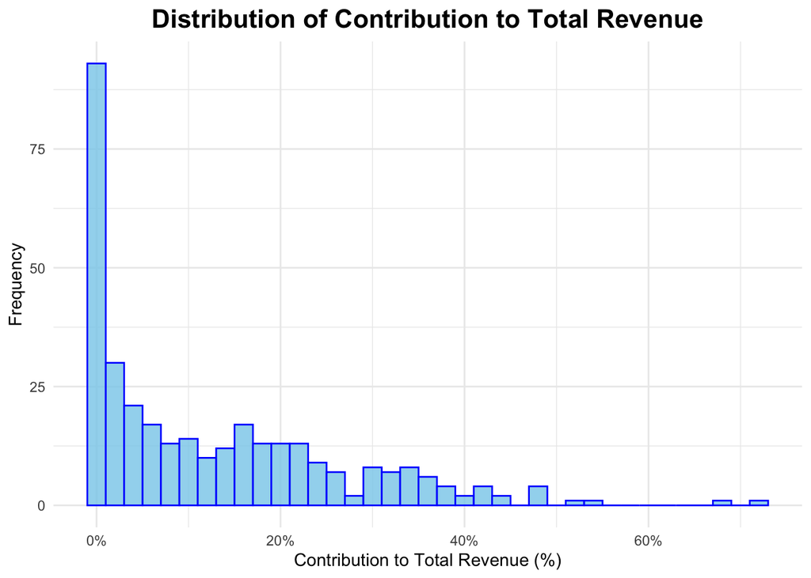

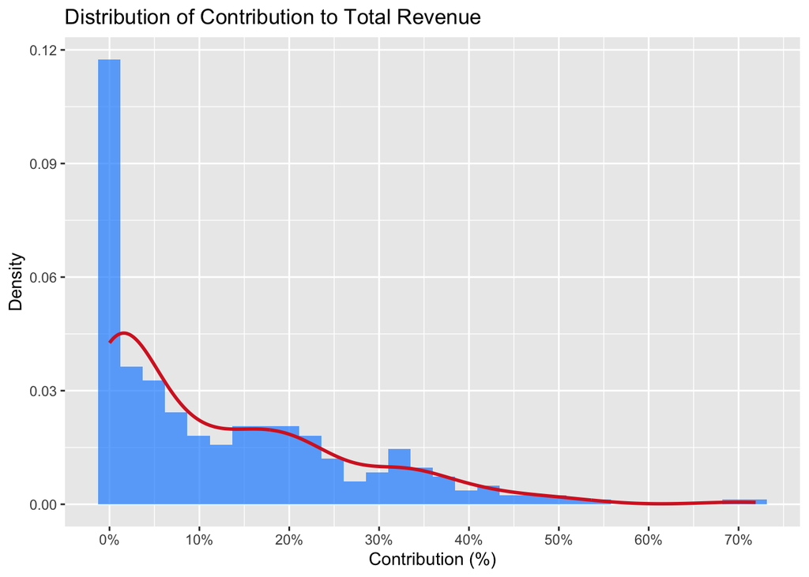

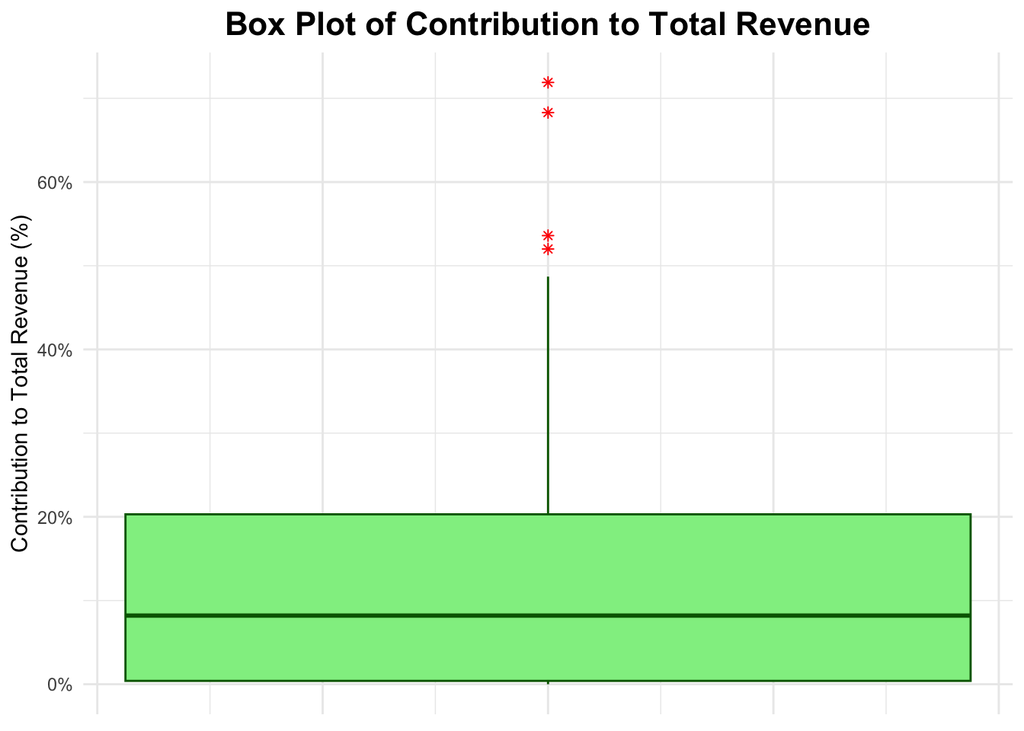

```
## --- Trend of Median Contribution to Total Revenue Over Years ---
```

| year | median_contribution |
| --- | --- |
| 2017 | 11.65 |
| 2018 | 6.70 |
| 2019 | 11.10 |
| 2020 | 10.35 |
| 2021 | 12.05 |
| 2022 | 6.90 |
| 2023 | 5.45 |
| 2024 | 3.80 |

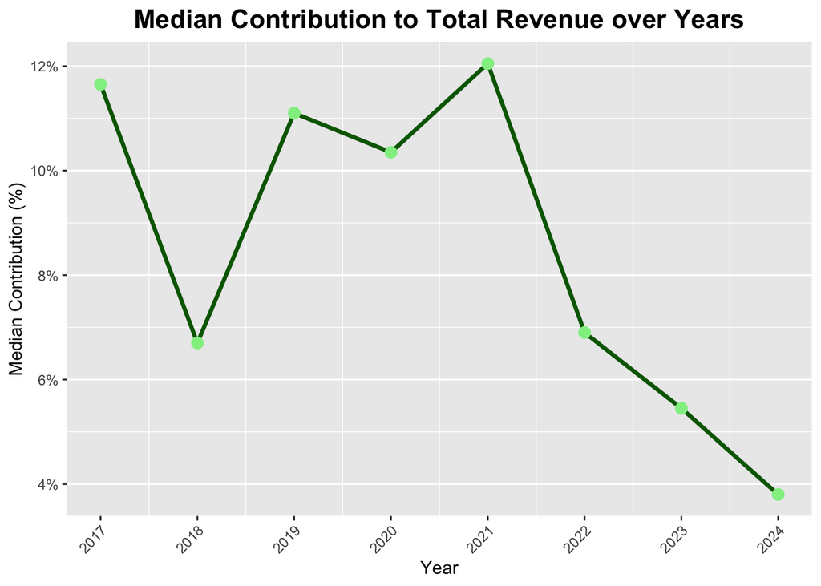

```
## --- Distribution of Contribution to Total Revenue by Year (Box Plots) ---
```

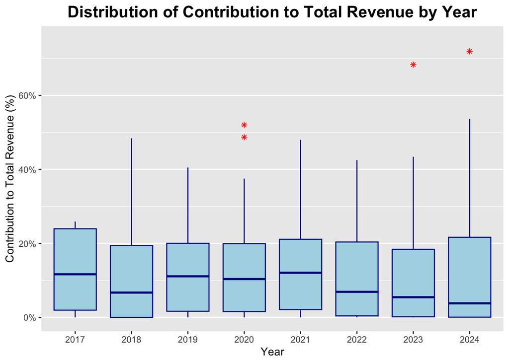

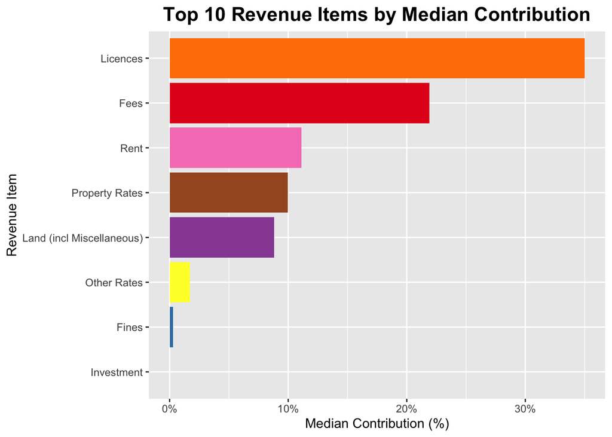

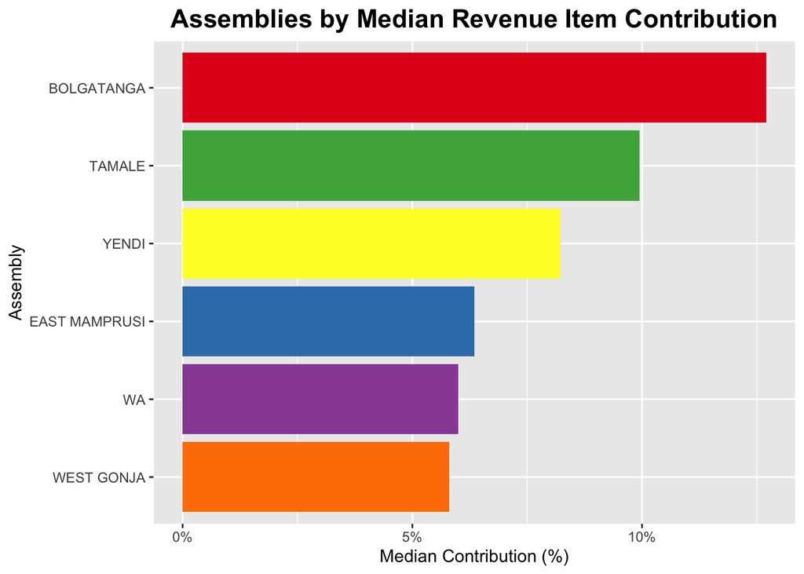

```
## --- Heatmap: Median Contribution to Total Revenue by Assembly and Year ---
```

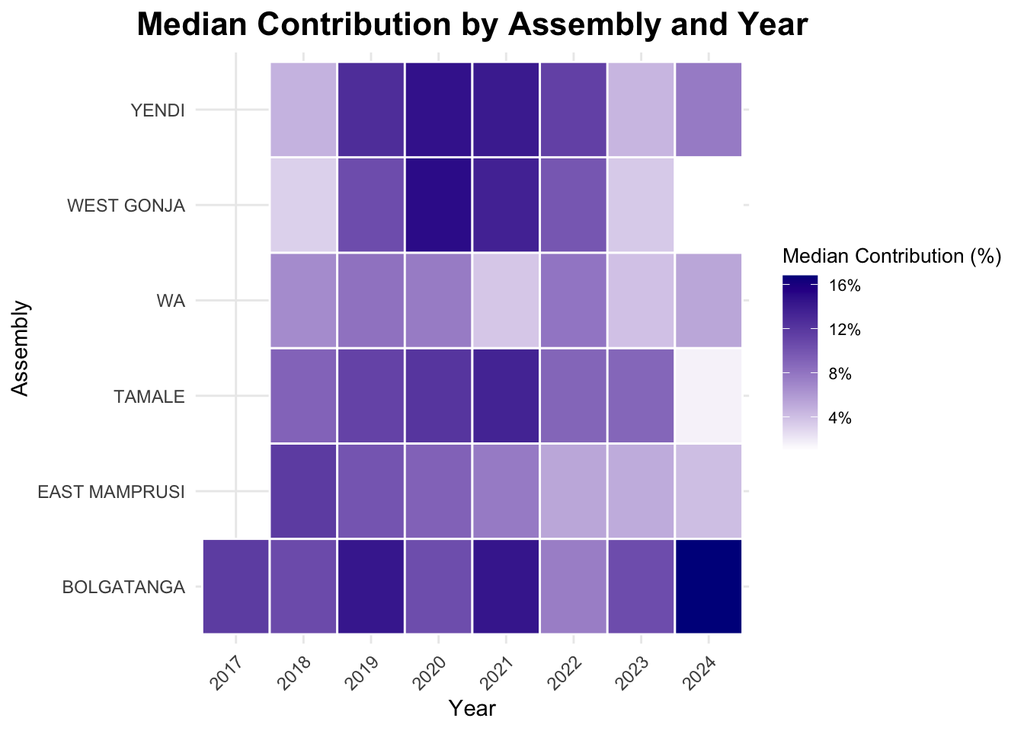

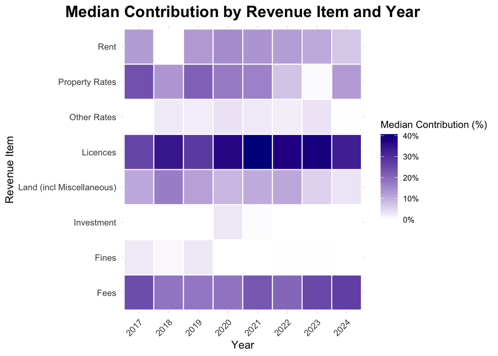

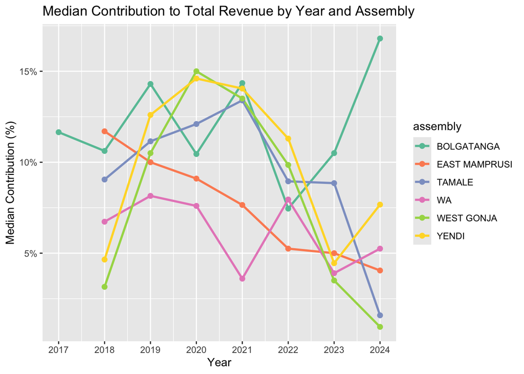

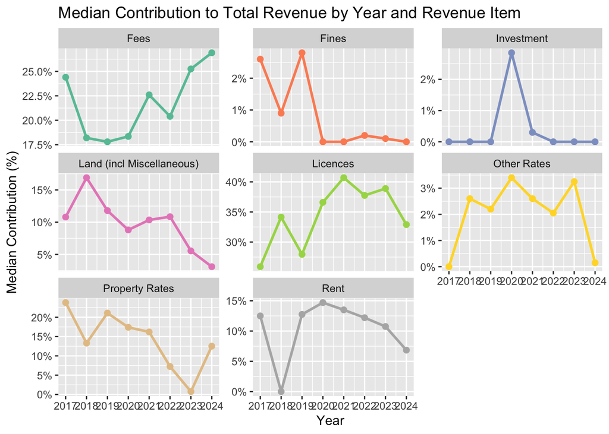

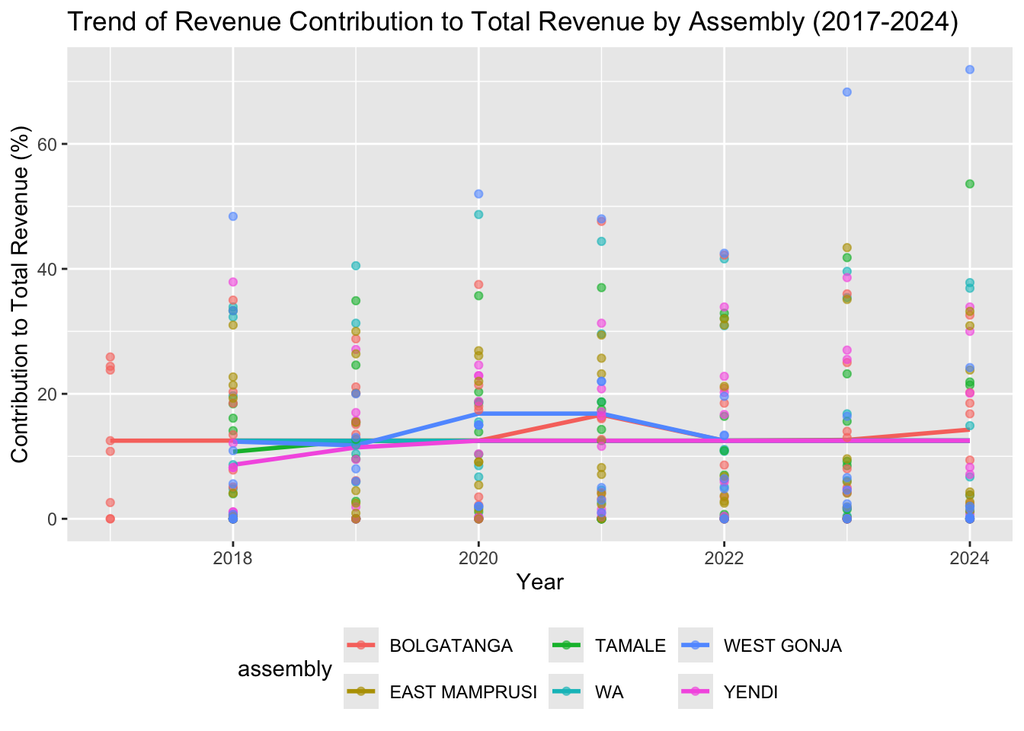

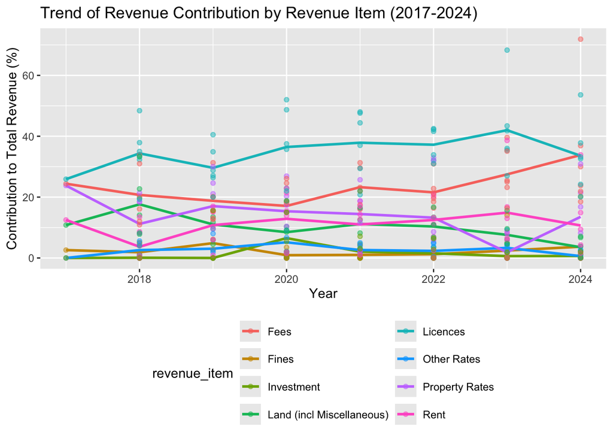

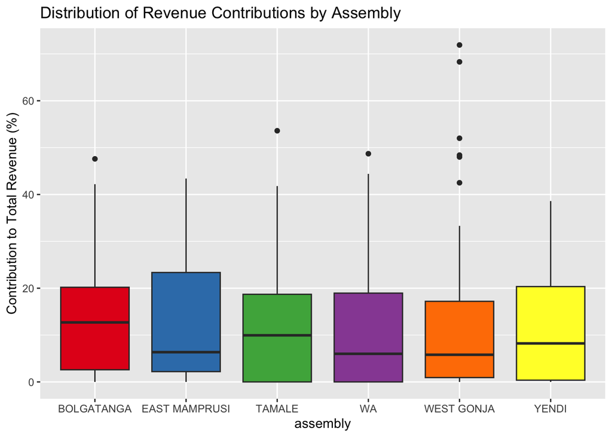

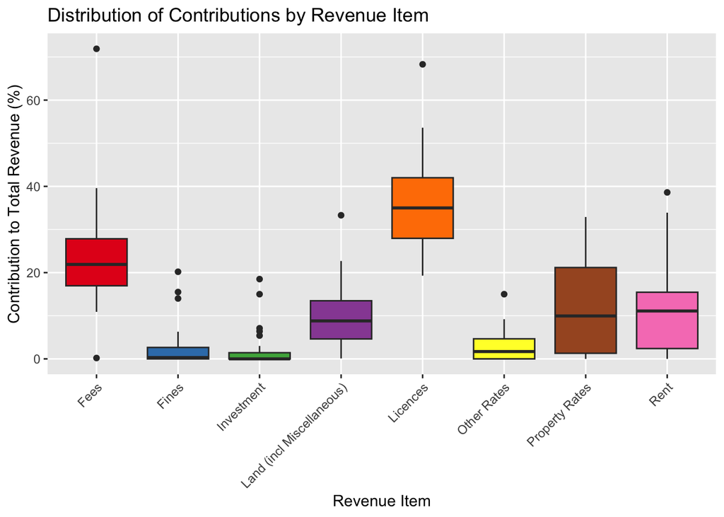

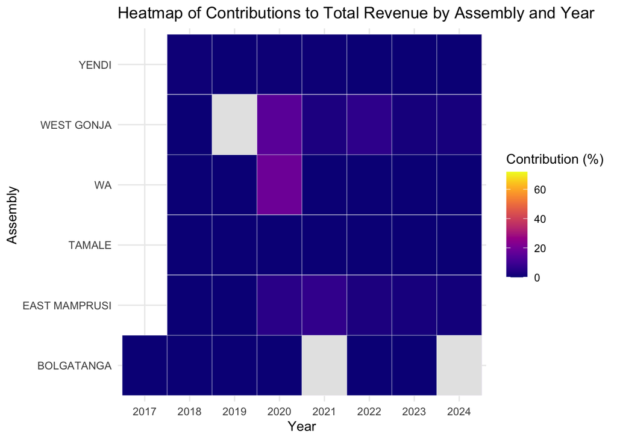

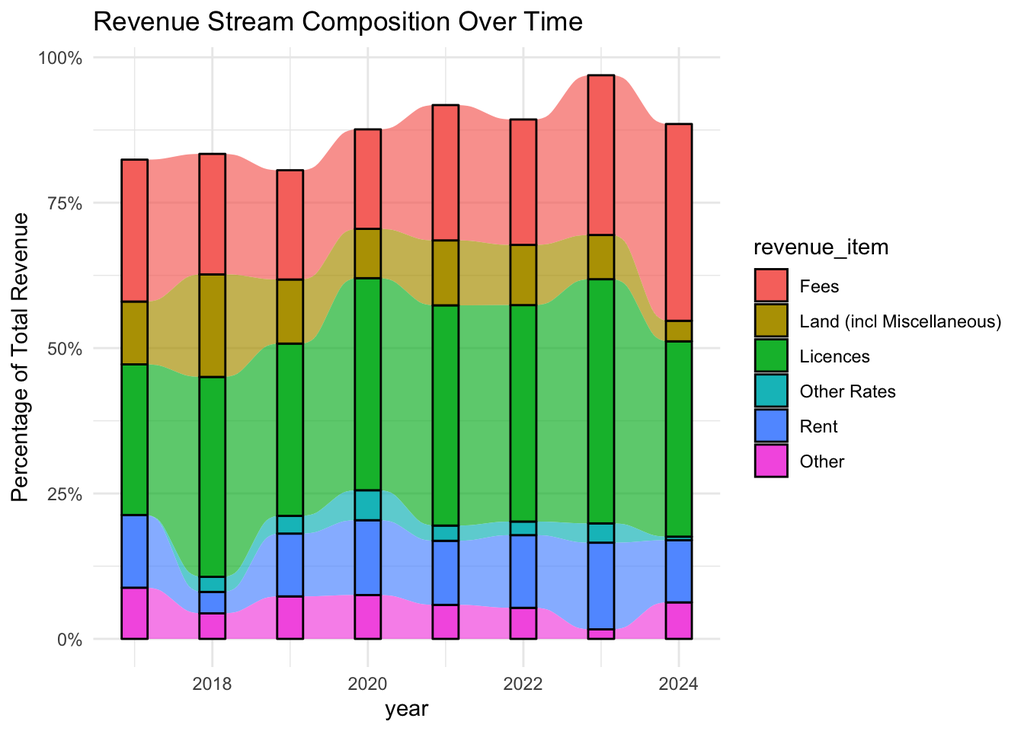

- Observations

Histograms: Right-skewed distribution, with most contributions <20%

Box Plots: Wide ranges for West Gonja (max = 71.9%) and Licences/Fees (medians 35%, 21.9%); tight ranges for Fines/Investment (medians ~0%). Outliers in 2023–2024 highlight high contributions.

The vsisuals confirm Licences/Fees’ reliability, 2023–2024 peaks, and regional disparities, aligning with rev_growth’s patterns.

Kruskal-Wallis Test: Contribution by Assembly

| Test | Chi_Squared | P_Value |
| --- | --- | --- |
| Kruskal-Wallis (Assembly) | 1.415 | 0.923 |

Kruskal-Wallis Test: Contribution by Revenue Item

| Test | Chi_Squared | P_Value |
| --- | --- | --- |
| Kruskal-Wallis (Revenue Item) | 212.228 | 0 |

Kruskal-Wallis Test: Significant differences across revenue items (χ² = 212.228, p < 0.001), indicating clear disparities ( Licences vs. Fines).

Kruskal-Wallis Test: No significant differences across assemblies (χ² = 1.415, p = 0.923)

Budget Planning: Prioritize Licences (median = 35%) and Fees (21.9%) for stable 2025 revenue, given their dominance. Anticipate lower contributions (median = 3.80% in 2024), per rev_growth’s decline (mean = -1.84%).

Data Validation: Verify outliers (e.g., 71.9% in West Gonja) and NA imputations, as in rev_growth (e.g., 66,911.2%).

# Conclusions

Dominance of Licences and Fees:

Finding: Licences (mean = 35.64%, median = 35.00%, max = 68.3%, 2023 peak) and Fees (mean = 23.27%, median = 21.90%, max = 71.9%, 2024 peak) are the primary contributors to total revenue, with 100% non-zero presence and significant differences from other items (Kruskal-Wallis p < 0.001). Visualizations (bar plots, alluvial plots) confirm their consistent high shares, especially post-2020.

Comparison with rev_growth: Mirrors their reliability (medians 14.35%, 13.90%), emphasizing stability across both contribution and growth metrics.

Conclusion: Licences and Fees are the backbone of revenue stability, making them critical for sustained fiscal planning.

Declining Median Contributions and Rising Inequality:

Finding: Median contributions drop from 12.05% (2021) to 3.80% (2024), despite stable means (~11.5–13.7%). Gini coefficients rise from 0.51 (2019) to 0.65 (2023–2024), and Shannon entropy falls from 3.32 (2019) to 3.09 (2024), indicating growing concentration in Licences/Fees. Line plots and box plots show outliers (max = 71.9% in 2024).

Comparison with rev_growth: Aligns with 2024’s decline (median = 0%, mean = -1.84%) and 2023’s peak (mean = 1479.85%), suggesting a shift toward fewer high-impact items.

Conclusion: Declining medians and increasing inequality signal reliance on key items, necessitating diversification strategies to mitigate risks.

Comparison with rev_growth: Bolgatanga’s consistency contrasts with its growth stagnation (median = 0%), while Tamale’s moderate contributions underperform its growth leadership (mean = 2047.67%).

Underperformance of Fines, Investment, and Other Rates:

Finding: Fines (mean = 2.31%, median = 0.30%), Investment (mean = 1.66%, median = 0.00%), and Other Rates (mean = 2.75%, median = 1.70%) contribute minimally, with frequent zero values (presence = 55.83–64.29%). Box plots show tight ranges, and alluvial plots likely depict their declining shares.

Comparison with rev_growth: Reflects Fines’ volatility (max = 43,990%) and Investment’s stagnation (median = 0%), indicating structural weaknesses.

Conclusion: These items are unreliable revenue sources, requiring policy reforms to enhance their contribution or reallocation of efforts to stronger items.

Temporal Peaks in 2023–2024 with Volatility:

Finding: High contributions in 2023 (Licences at 68.3%) and 2024 (Fees at 71.9%) align with increasing variability (SD = 16.43% in 2024). Heatmaps and line plots highlight these peaks, with 2017’s sparse data (N = 8, 2.3%) limiting early insights.

Comparison with rev_growth: Matches 2023’s growth spike ( Property Rates at 2418.6%) and 2024’s decline, suggesting shared economic or policy drivers (tax reforms).

Conclusion: The 2023–2024 peaks offer lessons for boosting contributions, but volatility underscores the need for stable revenue streams.

Policy and Strategic Implications Strengthen Licences and Fees: Enhance collection and enforcement mechanisms for Licences and Fees, given their dominant and stable contributions (medians 35%, 21.9%), to ensure reliable 2025 revenue.

Replicate 2023–2024 Successes: Investigate drivers of high contributions ( Fees at 71.9% in West Gonja, Licences at 68.3% in 2023) to replicate across assemblies, leveraging insights from rev_growth’s 2023 peaks.

Improve Weak Items: Reform Fines, Investment, and Other Rates (medians 0–1.70%) through policy changes ( better enforcement, investment incentives) or redirect efforts to stronger items, given their parallels in rev_growth.

Mitigate 2024 Decline: Prepare contingency budgets for 2025, anticipating continued low median contributions (3.80% in 2024), consistent with rev_growth’s decline (mean = -1.84%).

The contribution_to_rev analysis reveals a revenue landscape dominated by Licences and Fees, with significant contributions in 2023–2024 but declining medians and rising inequality by 2024. While assemblies show practical disparities ( Bolgatanga’s consistency, West Gonja’s volatility), statistical differences are limited to revenue items, driven by Licences/Fees’ dominance. Parallels with rev_growth underscore shared trends (2023 peaks, 2024 declines, regional gaps). For 2025, the assemblies should prioritize Licences/Fees, replicate 2023–2024 successes, and address underperforming items and regions to ensure fiscal stability.